# Check of Heterogeneity by Number of UK Affiliates within Parent Firms

# Purpose

This temporary note examines whether affiliate-level exit responses to the Brexit referendum differed between affiliates whose parent firms had only one UK affiliate in 2010 and affiliates whose parent firms had two or more UK affiliates in 2010.

The key idea is that parent firms with multiple UK affiliates may have more scope to reorganize within the UK after the referendum, for example by closing one affiliate while keeping other UK affiliates in place.

# Caveat

This is a reduced-form heterogeneity exercise at the affiliate level. It does not directly observe whether resources from a closed affiliate were actually reallocated to other surviving UK affiliates within the same parent firm.

```r
library(rio)
library(dplyr)
library(tidyr)
library(fixest)
library(knitr)
library(ggplot2)
```

# Parent-level UK affiliate counts in 2010

```r
# 親子関係を含む affiliate-level パネルデータを読み込む
parent_panel <- import("../../03_data_output/affiliate_panel_with_parent_links.dta") %>%
  filter(year == 2010)

# 2010 年時点での親企業ごとの UK affiliate 数を作る
parent_uk_count_2010 <- parent_panel %>%
  group_by(JPCode) %>%
  summarise(
    total_affiliates_2010 = n_distinct(AffiliateCode),
    uk_affiliates_2010 = n_distinct(AffiliateCode[iso == "GBR"]),
    any_uk_presence_2010 = uk_affiliates_2010 > 0,
    uk_multi_affiliate_group = case_when(
      uk_affiliates_2010 == 0 ~ "No UK affiliates",
      uk_affiliates_2010 == 1 ~ "One UK affiliate",
      uk_affiliates_2010 >= 2 ~ "Two or more UK affiliates",
      TRUE ~ NA_character_
    ),
    .groups = "drop"
  )

parent_uk_count_2010
```

```
## # A tibble: 3,583 × 5
##    JPCode total_affiliates_2010 uk_affiliates_2010 any_uk_presence_2010
##     <dbl>                 <int>              <int> <lgl>
##  1      2                     3                  0 FALSE
##  2      3                     1                  0 FALSE
##  3     12                     1                  0 FALSE
##  4     14                     1                  0 FALSE
##  5     27                     3                  0 FALSE
##  6     51                     2                  0 FALSE
##  7     58                     1                  0 FALSE
##  8     59                     1                  0 FALSE
##  9     61                     1                  0 FALSE
## 10     67                     2                  0 FALSE
## # ℹ 3,573 more rows
## # ℹ 1 more variable: uk_multi_affiliate_group <chr>
```

# Baseline exit sample

```r
# baseline の high-income EU exit sample を読み込む
exit_sample <- import("../../03_data_output/affiliate_panel_brexit_high_income_eu_sample.dta") %>%
  filter(year >= 2010, year <= 2020) %>%
  left_join(parent_uk_count_2010, by = "JPCode")

# exit sample の affiliate 数・親企業数などを確認する
exit_sample %>%
  summarise(
    affiliates = n_distinct(AffiliateCode),
    parents = n_distinct(JPCode),
    parents_with_uk_presence = n_distinct(JPCode[any_uk_presence_2010]),
    parents_with_multiple_uk_affiliates = n_distinct(JPCode[uk_affiliates_2010 >= 2])
  )
```

```
##   affiliates parents parents_with_uk_presence
## 1       1694     900                      381
##   parents_with_multiple_uk_affiliates
## 1                                  55
```

# Sample composition

```r
sample_composition <- exit_sample %>%
  group_by(uk_multi_affiliate_group) %>%
  summarise(
    parents = n_distinct(JPCode),
    affiliates = n_distinct(AffiliateCode),
    observations = n(),
    .groups = "drop"
  )

sample_composition %>%
  kable(caption = "Composition of the baseline exit sample by the number of UK affiliates within each parent firm")
```

Composition of the baseline exit sample by the number of UK affiliates within each parent firm

| uk_multi_affiliate_group | parents | affiliates | observations |
| --- | --- | --- | --- |
| No UK affiliates | 519 | 661 | 5288 |
| One UK affiliate | 326 | 689 | 5512 |
| Two or more UK affiliates | 55 | 344 | 2752 |

# Distribution of UK affiliate counts

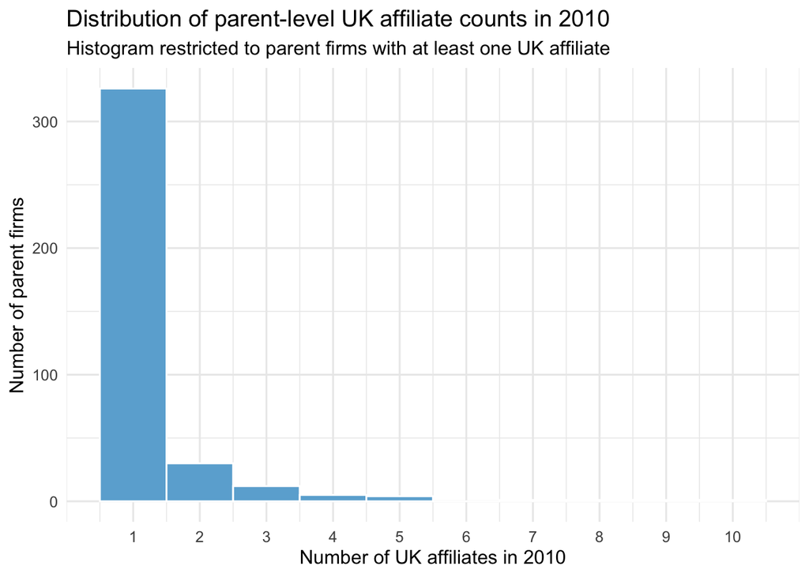

```r
parent_uk_count_dist <- exit_sample %>%
  distinct(JPCode, uk_affiliates_2010, uk_multi_affiliate_group)

ggplot(
  parent_uk_count_dist %>% filter(uk_affiliates_2010 > 0),
  aes(x = uk_affiliates_2010)
) +
  geom_histogram(binwidth = 1, boundary = 0.5, fill = "#6baed6", color = "white") +
  scale_x_continuous(breaks = seq(1, max(parent_uk_count_dist$uk_affiliates_2010, na.rm = TRUE), by = 1)) +
  labs(
    x = "Number of UK affiliates in 2010",
    y = "Number of parent firms",
    title = "Distribution of parent-level UK affiliate counts in 2010",
    subtitle = "Histogram restricted to parent firms with at least one UK affiliate"
  ) +
  theme_minimal(base_size = 12)
```

# Event-study estimates by the number of UK affiliates

```r
event_groups <- c("One UK affiliate", "Two or more UK affiliates")

event_parent_counts <- sample_composition %>%
  filter(uk_multi_affiliate_group %in% event_groups) %>%
  mutate(uk_multi_affiliate_group = factor(uk_multi_affiliate_group, levels = event_groups)) %>%
  arrange(uk_multi_affiliate_group)

event_samples <- split(
  exit_sample %>% filter(uk_multi_affiliate_group %in% event_groups),
  factor(
    exit_sample %>% filter(uk_multi_affiliate_group %in% event_groups) %>% pull(uk_multi_affiliate_group),
    levels = event_groups
  )
)

event_models <- lapply(
  event_samples,
  function(df) {
    feols(
      exitit ~ i(year, GBR, 2014) | year + AffiliateCode,
      data = df,
      vcov = ~country
    )
  }
)

extract_event_years <- function(model) {
  coef_names <- names(coef(model))
  as.numeric(sub(".*year::([0-9]{4}):GBR.*", "\\1", coef_names))
}

joint_test_pvalue <- function(model, years) {
  coef_names <- names(coef(model))
  test_terms <- coef_names[extract_event_years(model) %in% years]

  if (length(test_terms) == 0) {
    return(NA_real_)
  }

  b <- coef(model)[test_terms]
  V <- vcov(model)[test_terms, test_terms, drop = FALSE]
  V_inv_b <- tryCatch(
    solve(V, b),
    error = function(e) qr.solve(V, b)
  )
  wald_stat <- as.numeric(t(b) %*% V_inv_b)
  1 - pchisq(wald_stat, df = length(test_terms))
}

event_fit_stats <- tibble(
  uk_multi_affiliate_group = factor(names(event_models), levels = event_groups),
  N = sapply(event_models, nobs),
  pretrend_p = sapply(event_models, joint_test_pvalue, years = 2010:2015),
  post_p = sapply(event_models, joint_test_pvalue, years = 2016:2020)
) %>%
  left_join(event_parent_counts, by = "uk_multi_affiliate_group") %>%
  arrange(uk_multi_affiliate_group)

etable(
  event_models,
  keep = "%year::2010:GBR|year::2012:GBR|year::2016:GBR|year::2017:GBR|year::2018:GBR|year::2019:GBR|year::2020:GBR",
  fitstat = ~ n + wr2,
  tex = FALSE
)
```

```
##                   One UK affiliate Two or more UK ..
## Dependent Var.:             exitit            exitit
##
## GBR x year = 2010  0.0278 (0.0266)  0.0916* (0.0347)
## GBR x year = 2012  0.0093 (0.0174)  0.0663* (0.0269)
## GBR x year = 2016 -0.0020 (0.0225) -0.0385* (0.0129)
## GBR x year = 2017  0.0101 (0.0254) -0.0550* (0.0241)
## GBR x year = 2018 -0.0083 (0.0234) -0.0423* (0.0149)
## GBR x year = 2019  0.0034 (0.0213)  -0.0125 (0.0166)
## GBR x year = 2020  0.0105 (0.0194)  -0.0118 (0.0273)
## Fixed-Effects:    ---------------- -----------------
## year                           Yes               Yes
## AffiliateCode                  Yes               Yes
## _________________ ________________ _________________
## S.E.: Clustered        by: country       by: country
## Observations                 5,512             2,752
## Within R2                  0.00049           0.00931
## ---
## Signif. codes: 0 '***' 0.001 '**' 0.01 '*' 0.05 '.' 0.1 ' ' 1
```

```r
event_test_results <- event_fit_stats %>%
  transmute(
    `Group` = as.character(uk_multi_affiliate_group),
    `Pre-trend test p-value` = round(pretrend_p, 3),
    `Post-treatment joint test p-value` = round(post_p, 3)
  )

kable(
  event_test_results,
  caption = "Joint tests for pre-trends and post-treatment effects by the number of UK affiliates within each parent firm"
)
```

Joint tests for pre-trends and post-treatment effects by the number of UK affiliates within each parent firm

| Group | Pre-trend test p-value | Post-treatment joint test p-value |
| --- | --- | --- |
| One UK affiliate | 0.293 | 0 |
| Two or more UK affiliates | 0.029 | 0 |

# Event-study plot

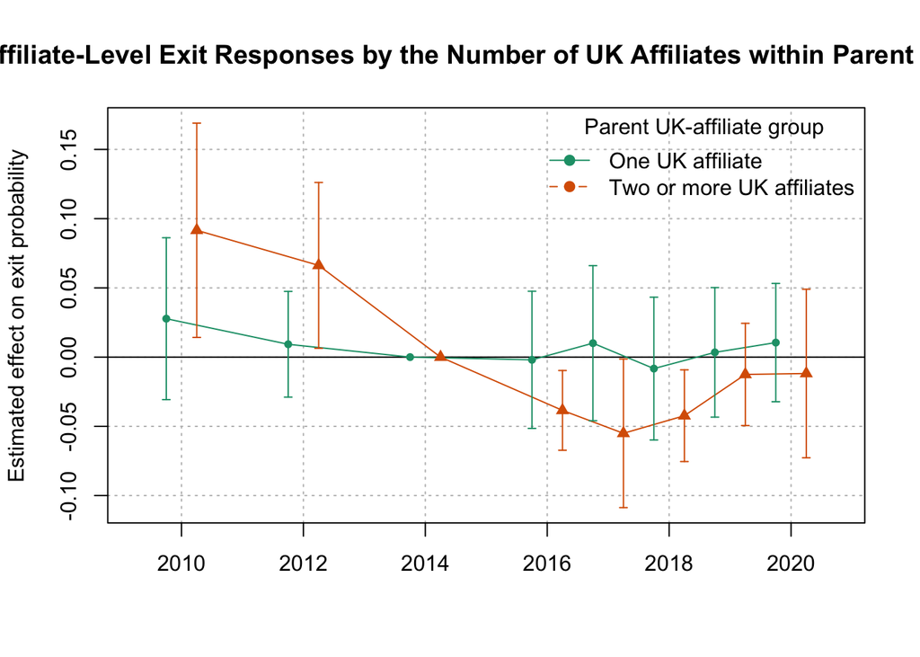

```r
legend_labels <- as.character(event_fit_stats$uk_multi_affiliate_group)

note_line_one <- sprintf(
  "One UK affiliate: N = %s, Parent firms = %s, Affiliates = %s, Observations = %s.",
  event_fit_stats$N[event_fit_stats$uk_multi_affiliate_group == "One UK affiliate"],
  event_fit_stats$parents[event_fit_stats$uk_multi_affiliate_group == "One UK affiliate"],
  event_fit_stats$affiliates[event_fit_stats$uk_multi_affiliate_group == "One UK affiliate"],
  event_fit_stats$observations[event_fit_stats$uk_multi_affiliate_group == "One UK affiliate"]
)

note_line_multi <- sprintf(
  "Two or more UK affiliates: N = %s, Parent firms = %s, Affiliates = %s, Observations = %s.",
  event_fit_stats$N[event_fit_stats$uk_multi_affiliate_group == "Two or more UK affiliates"],
  event_fit_stats$parents[event_fit_stats$uk_multi_affiliate_group == "Two or more UK affiliates"],
  event_fit_stats$affiliates[event_fit_stats$uk_multi_affiliate_group == "Two or more UK affiliates"],
  event_fit_stats$observations[event_fit_stats$uk_multi_affiliate_group == "Two or more UK affiliates"]
)

plot_event_study <- function() {
  do.call(
    iplot,
    c(
      event_models,
      list(
        pt.join = TRUE,
        sep = 0.5,
        ref.line = 0,
        xlab = "",
        ylab = "Estimated effect on exit probability",
        main = "Affiliate-Level Exit Responses by the Number of UK Affiliates within Parent Firms",
        ci_level = 0.95,
        col = c("#1b9e77", "#d95f02"),
        pt.col = c("#1b9e77", "#d95f02")
      )
    )
  )

  legend(
    "topright",
    legend = legend_labels,
    col = c("#1b9e77", "#d95f02"),
    pch = 19,
    lty = 1:2,
    lwd = 1,
    bty = "n",
    title = "Parent UK-affiliate group"
  )
}

plot_event_study()
```

```r
cat(
  paste0(
    "**Figure note.** ",
    note_line_one,
    "<br>",
    note_line_multi
  )
)
```

**Figure note.** One UK affiliate: N = 5512, Parent firms = 326, Affiliates = 689, Observations = 5512.  
Two or more UK affiliates: N = 2752, Parent firms = 55, Affiliates = 344, Observations = 2752.

# Interpretation

This note is intended as a feasibility check. If affiliates belonging to parent firms with multiple UK affiliates show a larger exit response, one possible interpretation is that parent firms may have had more scope to reorganize within the UK while preserving some UK presence.